# Project2

Adam Ruthford

12/2/2019

# Links to Project Video

Link to Project Video: [Attrition Analysis for DDSAnalytics](https://youtu.be/1XWhjPP17Z8)

# EDA

## Examine distribution of existing data variables

The various data points were examined in an attempt to learn exactly how each impacted employee retention. As an example employee stock option levels were analyzed with respect to attrition

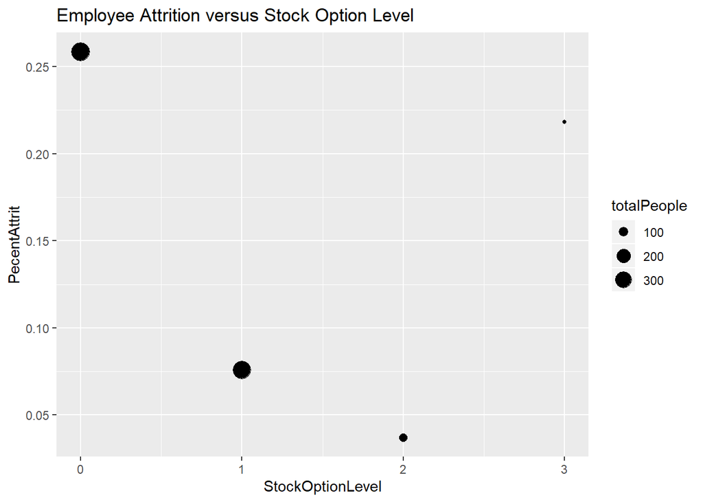

```r
AFSOL <- AF %>% group_by(StockOptionLevel) %>% summarise(PecentAttrit = sum(AtrY)/n(), totalPeople = n())
ggplot(data = AFSOL, mapping = aes(x= StockOptionLevel, y=PecentAttrit, size=totalPeople)) + ggtitle("Employee Attrition versus Stock Option Level") +
  geom_point(stat = "identity")
```

The chart above indicates that employees in the lowest stock option level group and the highest stock option group have the highest turnover. Similar charts were prepared for each categorical variable.

## Derived Variables

Looking at all the variables suggested that derived variables could be created and used to a positive benefit in the model. StockOptionLevel was one such variable, a derived variable that contains a simple yes/no value with yes being for StockOptionLevel 0 or 3. The final list of derived variables is shown below

```r
AF$SO30 <- ifelse(AF$StockOptionLevel == 3 | AF$StockOptionLevel == 0,1,0)
AF$MIbyE <- AF$MonthlyIncome/AF$Education
AF$isSingle <- ifelse(AF$MaritalStatus == "Single",1,0)
AF$YCR02 <- ifelse(AF$YearsInCurrentRole <= 2,1,0)
AF$SO3 <- ifelse(AF$StockOptionLevel == 3,1,0)
AF$SO0 <- ifelse(AF$StockOptionLevel == 0,1,0)
AF$isJS1 <- ifelse(AF$JobSatisfaction == 1,1,0)
AF$isJS4 <- ifelse(AF$JobSatisfaction == 4,1,0)
```

# Model Selection

Two different types of models were considered for this analysis, kNN and Naïve Bayes.

## Selection Criteria

Whatever model selected was required to have both a sensitivity and specificity of 60%. Sensitivity was not a problem, even the most rudimentary model typically met this criteria. The required specificity was not so easily obtained. Since we are dealing with an attrition rate of one in six roughly we can see that it would be difficult to randomly get the correct result. Conversely we could just predict there was no attrition and we would have a better than 80% accuracy.

## kNN

The kNN model was ultimately rejected. I was unable to get a specificity reading higher than the mid 30’s.

### kNN Optimization Process

A series of derived variables was created for this model as well, many of these variables being scaled inputs. Each variables was then run against all other variables in a two variable kNN model. The most likely candidates were then run against each other again in a three variable kNN model.  
ScaleOverTime - Scaled OverTime  
isJL1 - JobLevel = 1  
isSingle - MaritialStatus is Single  
ScaleMonthlyIncome - MonthlyIncolme scaled  
SO30 - StockOptionsLevel either 0 or 3  
isTWY03 - TotalWorkingYears less than or equal to 3  
ScaleYearsWithCurrManager - YearsWithCurrManager with current manager scaled

Once that was done the remaing likely candidates were run against each other by hand. Also, a loop was created to optimize the “k” parameter. The final kNN model is shown below with results.

```r
# variables only used in kNN final model
AF$ScaleOverTime = scale(as.numeric(AF$OverTime))
AF$ScaleMonthlyIncome = scale(AF$MonthlyIncome)
AF$isJL1 <- ifelse(AF$JobLevel == 1,1,0)

testParam <- c("ScaleOverTime","isSingle","ScaleMonthlyIncome","isJL1")

AFAttrit <- knn.cv(AF[,testParam], AF$Attrition, k = 11)
CM <- confusionMatrix(table(AFAttrit, AF$Attrition))
```

For the final kNN model:  
Accuracy = 86.2068966%  
Sensitivity = 95.890411%  
Specificity = 35.7142857%

## Naïve Bayes

After many iterations a successful version of a Naïve Bayes model was created

### Naïve Bayes Optimization Process

#### Derived Variables

First some derived variables were created similiar to those created for the kNN model

```r
AF$MIbyE <- AF$MonthlyIncome/AF$Education
AF$isSingle <- ifelse(AF$MaritalStatus == "Single",1,0)
AF$SO30 <- ifelse(AF$StockOptionLevel == 3 | AF$StockOptionLevel == 0,1,0)
AF$isAgeLE22 <- ifelse(AF$Age <= 22,1,0)
AF$isJL1 <- ifelse(AF$JobLevel == 1,1,0)
AF$isJI1 <- ifelse(AF$JobInvolvement == 1,1,0)
```

#### List of Column names

A varaible containing a list of column names was prepared. Considering the information learned in the EDA process some Columns were judged of no impact to the final model and were removed.

```r
AFColNam <- colnames(AF)

#Remove columns we dont need to train on
SkipName <- c("ID","Attrition","EmployeeCount","EmployeeNumber","Over18","StandardHours")

AFColNam <- AFColNam[!AFColNam %in% SkipName]
```

#### Testing loop

A loop was then prepared to test each combination of two columns. This took several hours to run and the results were written to a file. This part is not run as part of this document since it would take the page several hours to complete

```r
# Setup things used by model repeatedly

trainControl <- trainControl(method = "cv", number = 10)

# set up tuning grid
search_grid <- expand.grid(
  usekernel = c(TRUE, FALSE),
  fL = 0:5,
  adjust = seq(0, 5, by = 1)
)

y = trainAF$Attrition

#Setup begin end list for
testOffset = 0

EndA1 <- length(AFColNam) - 1 - testOffset
EndA2 <- length(AFColNam) - testOffset

# Results dataframe

dfRes <- data.frame(Attribute1 = character(), Attribute2 = character(),
                    Acc = numeric(), Sens = numeric(), Spec = numeric(),
                    stringsAsFactors = FALSE)

for (A1 in seq(1,EndA1)){
  BeginA2 = A1 + 1
  for (A2 in seq(BeginA2,EndA2)){

    testParam <- c(AFColNam[A1],AFColNam[A2])
    x = trainAF[,testParam]

    nb.m2 <- train(
      x = x,
      y = y,
      method = "nb",
      trControl = trainControl,
      tuneGrid = search_grid,
      preProc = c("BoxCox", "center", "scale") #, "pca"
    )

    CM = confusionMatrix(table(predict(nb.m2,testAF[,testParam]),testAF$Attrition))

    Acc <- unname(CM[[3]][c('Accuracy')])
    Sens <- unname(CM[[4]][c('Sensitivity')])
    Spec <- unname(CM[[4]][c('Specificity')])

    dfRes[nrow(dfRes) + 1,] <- c(AFColNam[A1],AFColNam[A2], Acc, Sens, Spec)

    prnStr <- paste(AFColNam[A1],AFColNam[A2])
    print(prnStr)
  }
}

write.csv(dfRes, file = "NBOptimize.csv", row.names = FALSE, na="")
```

#### Conclusion form testing loop

After the file was examined a winowing of columns was performed with only the best used to further build the model. However, this failed to create a model with anywhere near the desired sensitivity and specificity.

#### All Columns model

Instead a different approach was tried. All columns, including derived columns, were included in a model. The model was then run with one column at a time being removed. If there was no change in the model or the model performed better the column was kept out. The code below shows the various columns commented out.

```r
trainIndices = sample(seq(1:length(AF$Age)),round(.8*length(AF$Age)))
trainAF = AF[trainIndices,]
testAF = AF[-trainIndices,]

m <- naiveBayes(Attrition ~
                  #Age +
                  #BusinessTravel +
                  #DailyRate +
                  #Department +
                  DistanceFromHome +
                  #Education +
                  EducationField +
                  #EmployeeCount +
                  #EnvironmentSatisfaction +
                  #Gender +
                  #HourlyRate +
                  #JobInvolvement +
                  #JobLevel +
                  JobRole +
                  JobSatisfaction +
                  #MaritalStatus +
                  MonthlyIncome +
                  #MonthlyRate +
                  #NumCompaniesWorked +
                  OverTime +
                  #PercentSalaryHike +
                  PerformanceRating +
                  #RelationshipSatisfaction +
                  StockOptionLevel +
                  TotalWorkingYears +
                  TrainingTimesLastYear +
                  #WorkLifeBalance +
                  #YearsAtCompany +
                  YearsInCurrentRole +
                  #YearsSinceLastPromotion +
                  #YearsWithCurrManager +
                  MIbyE +
                  isSingle +
                  SO30
                  #isAgeLE22 +
                  #isJL1 +
                  #isJI1
                  ,
                  data = trainAF, laplace = 1)
pred <- predict(m, testAF)
confusionMatrix(table(pred, testAF$Attrition))
```

```
## Confusion Matrix and Statistics
##
##
## pred   No Yes
##   No  135  11
##   Yes  16  12
##
##                Accuracy : 0.8448
##                  95% CI : (0.7823, 0.8952)
##     No Information Rate : 0.8678
##     P-Value [Acc > NIR] : 0.8433
##
##                   Kappa : 0.3807
##
##  Mcnemar's Test P-Value : 0.4414
##
##             Sensitivity : 0.8940
##             Specificity : 0.5217
##          Pos Pred Value : 0.9247
##          Neg Pred Value : 0.4286
##              Prevalence : 0.8678
##          Detection Rate : 0.7759
##    Detection Prevalence : 0.8391
##       Balanced Accuracy : 0.7079
##
##        'Positive' Class : No
##
```

#### Conclusioin from All Columns model

This model was in the ball park with the average specificity approaching the 60% mark, individual runs maybe well short of that mark. Sensitivity and accuracy are both fine.